# Cell Growth Curve and Concentration Response Analysis

Zachery Moore

22 October 2026

# 1 Objective

The `dosefitr` package provides tools for analysing cell growth curves and the subsequenet calculation of doubling rates. This vignette walks through the main functionality using an example dataset included with the package.

# 2 Loading and visualising data

First, load the package.

```r
library(dosefitr)
```

The `double_data` dataset contains longitudinal measurements of spheroid area, acquired on the IncuCyte, at two seeding densities (1000 and 2000 cells). We start by plotting area over time, coloured by seeding density.

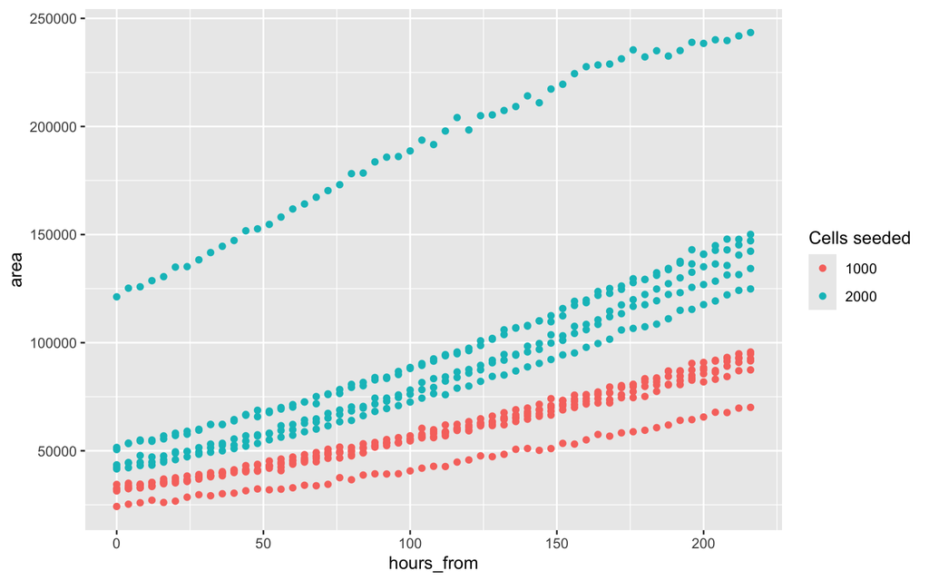

```r
data("double_data", package = "dosefitr")

double_data_filt <- double_data |>
  dplyr::select(cells_seeded, hours_from, area)

ggplot2::ggplot(
  double_data_filt,
  ggplot2::aes(hours_from, area, colour = as.factor(cells_seeded))
) +
  ggplot2::geom_point() +
  ggplot2::labs(colour = "Cells seeded")
```

# 3 Fitting growth models

`fit_curve()` fits a growth model to the data. Here we use `five_param_sigmoid`. Parameters can be shared between experimental groups to improve fitting stability: `shared_group` specifies the column holding the grouping variable (seeding density), and `shared_parameters` specifies which model parameters are shared. Here we share `top` (maximum growth) and `slope`.

```r
double_model <- fit_curve(
  data = double_data_filt,
  x_var = "hours_from",
  y_var = "area",
  curve_options = list(model = "five_param_sigmoid"),
  shared_options = list(
    shared_group = "cells_seeded",
    shared_parameters = c("top", "slope")
  )
)
```

The fitted `nls` object contains the parameter estimates for each curve.

```r
double_model$curve$nls_model
```

```
## Nonlinear regression model
##   model: y ~ f(x, top, slope, bottom_1000, bottom_2000, s_1000, s_2000,     ec50_1000, ec50_2000, group)
##    data: data
##         top       slope bottom_1000   ec50_1000      s_1000 bottom_2000
##   1.799e+05   8.569e+00   3.187e+04   2.657e+02   1.484e-01   5.969e+04
##   ec50_2000      s_2000
##   1.415e+02   1.435e-01
##  residual sum-of-squares: 5.126e+11
##
## Number of iterations till stop: 50
## Achieved convergence tolerance: 1.49e-08
## Reason stopped: Number of iterations has reached `maxiter' == 50.
```

We can then visualise the fit.

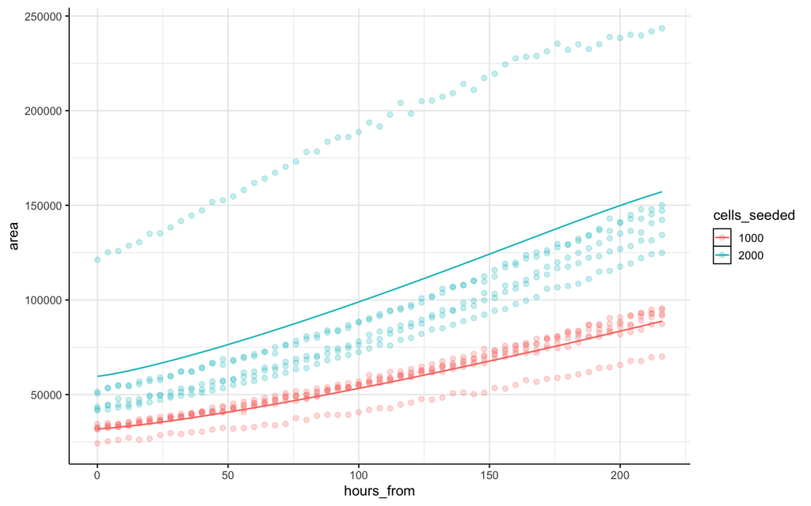

```r
plot_model(
  list = double_model,
  x_var = "hours_from",
  y_var = "area"
)
```

# 4 Handling outliers

Experimental data often contain outliers that can distort model fits. Setting `huber = TRUE` uses a Huber loss to down-weight the influence of extreme points during fitting, and `rout = TRUE` uses the ROUT method to identify and remove outliers. Outliers are highlighted in the resulting plot.

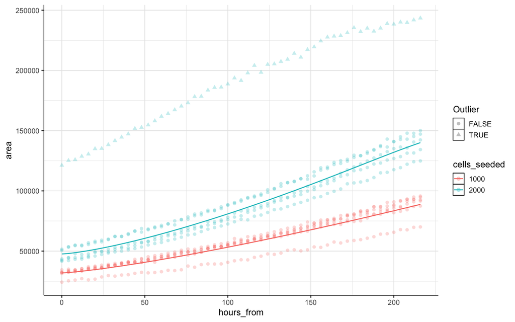

```r
double_model_outlier <- fit_curve(
  data = double_data_filt,
  x_var = "hours_from",
  y_var = "area",
  curve_options = list(model = "five_param_sigmoid"),
  shared_options = list(
    shared_group = "cells_seeded",
    shared_parameters = c("top", "slope")
  ),
  outlier_options = list(huber = TRUE, rout = TRUE)
)

plot_model(
  list = double_model_outlier,
  x_var = "hours_from",
  y_var = "area"
)
```

# 5 Calculating doubling times

Doubling time is a key metric for growth analysis. We first use `predict_data()` to generate smooth predicted curves from the fitted model for each seeding density.

```r
double_model_predicted <- lapply(
  c(1000, 2000),
  function(group) {
    predict_data(
      nls_model = double_model$curve$nls_model,
      lower_x = min(double_model$data$hours_from),
      upper_x = max(double_model$data$hours_from),
      group = group
    )
  }
) |>
  dplyr::bind_rows() |>
  dplyr::rename(hours_from = x, area = y, cells_seeded = group)
```

`calc_double_rate_data()` then calculates the doubling time from these predicted curves. Because spheroid area is a two-dimensional readout of a three-dimensional object, `doubling_readout_factor` converts the area change to the equivalent change in volume (here `2^(2/3)`, assuming spherical spheroids). For confluence or direct cell counts, set this to 1. The function also returns diagnostic plots showing the growth curves and the points used in the calculation.

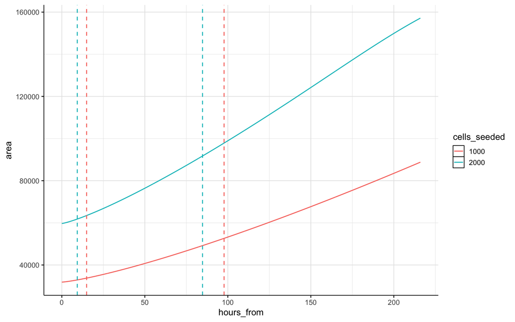

```r
double_rate <- calc_double_rate_data(
  data = double_model_predicted,
  x_var = "hours_from",
  y_var = "area",
  cell_column = "cells_seeded",
  doubling_readout_factor = 2^(2 / 3)
)

# Diagnostic plots
double_rate$linear
```

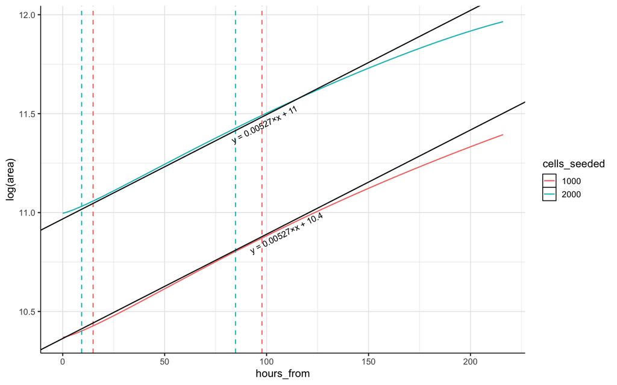

```r
double_rate$log
```

```r
# Doubling time
double_rate$double_time
```

```
## [1] 87.66387
```